# Assignment 02

Author

Giuliet Kibler

## Due Date

This assignment is due by 11:59pm Pacific Time, October 11th, 2024.

For this assignment, we will be analyzing data from USC’s Children’s Health Study.

The learning objectives are to conduct data wrangling and visualize the data with key questions in mind.

## Data Wrangling

You will need to download two datasets from https://github.com/USCbiostats/data-science-data. The [individual](https://raw.githubusercontent.com/USCbiostats/data-science-data/master/01_chs/chs_individual.csv) and [regional](https://raw.githubusercontent.com/USCbiostats/data-science-data/master/01_chs/chs_regional.csv) CHS datasets in `01_chs`. The individual data includes personal and health characteristics of children in 12 communities across Southern California. The regional data include air quality measurements at the community level. Once downloaded, you can merge these datasets using the location variable. Once combined, you will need to do the following:

```r
# Load Libraries
library(dplyr)
library(tidyr)
library(ggplot2)
library(leaflet)
library(RColorBrewer)
```

```r
# Load in data tables
individual_data_url <- 'https://raw.githubusercontent.com/USCbiostats/data-science-data/master/01_chs/chs_individual.csv'
regional_data_url <- 'https://raw.githubusercontent.com/USCbiostats/data-science-data/master/01_chs/chs_regional.csv'

individual_data <- read.csv(individual_data_url)
regional_data <- read.csv(regional_data_url)
```

1. After merging the data, make sure you don’t have any duplicates by counting the number of rows. Make sure it matches.

   ```r
   # Merge data
   merged_data <- merge(individual_data, regional_data, by = "townname")

   # Check for duplicates
   initial_row_count <- nrow(merged_data)
   merged_data <- merged_data |>
     distinct()
   final_row_count <- nrow(merged_data)

   if (initial_row_count == final_row_count) {
     print("No duplicates found.")
   } else {
     print(paste("Duplicates removed. Rows before:", initial_row_count, ", Rows after:", final_row_count))
   }
   ```

   ```
   [1] "No duplicates found."
   ```

   ```r
   # There are no duplicates
   ```

   In the case of missing values, impute data using the average amongst individuals with the same values for the “male” and “hispanic” variables. For categorical variables, take the mode. If you are interested (and feel adventurous) in the theme of Data Imputation, take a look at this paper on “Multiple Imputation” using the Amelia R package [here](https://gking.harvard.edu/files/gking/files/amelia_jss.pdf).

   ```r
   # Impute missing values
   merged_data <- merged_data |>
     group_by(male, hispanic) |>
     mutate(
       across(where(is.numeric), ~ ifelse(is.na(.), mean(., na.rm = TRUE), .)),
       across(where(is.character), ~ ifelse(is.na(.),
         as.character(na.omit(.)[which.max(table(na.omit(.)))]), .))
     ) |>
     ungroup()
   ```

2. Create a new categorical variable named “obesity_level” using the BMI measurement (underweight BMI<14; normal BMI 14-22; overweight BMI 22-24; obese BMI>24). To make sure the variable is rightly coded, create a summary table that contains the minimum BMI, maximum BMI, and the total number of observations per category.

   ```r
   # Create obesity_level variable
   merged_data <- merged_data |>
     mutate(obesity_level = case_when(
       bmi < 14 ~ 'underweight',
       bmi >= 14 & bmi <= 22 ~ 'normal',
       bmi > 22 & bmi <= 24 ~ 'overweight',
       bmi > 24 ~ 'obese'
     ))

   # Summarize obesity_level
   obesity_summary <- merged_data |>
     group_by(obesity_level) |>
     summarise(min_BMI = min(bmi, na.rm = TRUE),
               max_BMI = max(bmi, na.rm = TRUE),
               count = n()) |>
     ungroup()
   print(obesity_summary)
   ```

   ```
   # A tibble: 4 × 4
     obesity_level min_BMI max_BMI count
     <chr>           <dbl>   <dbl> <int>
   1 normal           14.0    22.0   975
   2 obese            24.0    41.3   103
   3 overweight       22.0    24.0    87
   4 underweight      11.3    14.0    35
   ```

3. Create another categorical variable named “smoke_gas_exposure” that summarizes “Second Hand Smoke” and “Gas Stove.” The variable should have four categories in total.

   ```r
   # Creare smoke_gas_exposure variable
   merged_data <- merged_data |>
     mutate(smoke_gas_exposure = case_when(
       smoke >= 0.5 & gasstove >= 0.5 ~ 'both', # 0.5 chosen to account for averaged data
       smoke >= 0.5 ~ 'smoke',
       gasstove >= 0.5 ~ 'gas',
       TRUE ~ 'none'
     ))

   smoke_gas_summary <- merged_data |>
     group_by(smoke_gas_exposure) |>
     summarise(min_gas = min(gasstove, na.rm = TRUE),
               max_gas = max(gasstove, na.rm = TRUE),
               min_smoke = min(smoke, na.rm = TRUE),
               max_smoke = max(smoke, na.rm = TRUE),
               count = n()) |>
     ungroup()
   print(smoke_gas_summary)
   ```

   ```
   # A tibble: 4 × 6
     smoke_gas_exposure min_gas max_gas min_smoke max_smoke count
     <chr>                <dbl>   <dbl>     <dbl>     <dbl> <int>
   1 both                 0.729       1         1     1       154
   2 gas                  0.729       1         0     0.195   791
   3 none                 0           0         0     0.154   219
   4 smoke                0           0         1     1        36
   ```

4. Create four summary tables showing the average (or proportion, if binary) and sd of “Forced expiratory volume in 1 second (ml)” (an asthma indicator) by town, sex, obesity level, and “smoke_gas_exposure.”

   ```r
   ## Summary tables
   # By town
   summary_by_town <- merged_data |>
     group_by(townname) |>
     summarise(mean_fev = mean(fev, na.rm = TRUE),
               sd_fev = sd(fev, na.rm = TRUE)) |>
     ungroup()
   print(summary_by_town)
   ```

   ```
   # A tibble: 12 × 3
      townname      mean_fev sd_fev
      <chr>            <dbl>  <dbl>
    1 Alpine           2087.   291.
    2 Atascadero       2076.   324.
    3 Lake Elsinore    2039.   304.
    4 Lake Gregory     2085.   320.
    5 Lancaster        2003.   317.
    6 Lompoc           2034.   351.
    7 Long Beach       1986.   319.
    8 Mira Loma        1985.   325.
    9 Riverside        1990.   278.
   10 San Dimas        2027.   319.
   11 Santa Maria      2026.   312.
   12 Upland           2024.   343.
   ```

   ```r
   # By sex
   summary_by_sex <- merged_data |>
     group_by(male) |>
     summarise(mean_fev = mean(fev, na.rm = TRUE),
               sd_fev = sd(fev, na.rm = TRUE)) |>
     ungroup()
   print(summary_by_sex)
   ```

   ```
   # A tibble: 2 × 3
      male mean_fev sd_fev
     <int>    <dbl>  <dbl>
   1     0    1959.   312.
   2     1    2104.   308.
   ```

   ```r
   # By obesity_level
   summary_by_obesity <- merged_data |>
     group_by(obesity_level) |>
     summarise(mean_fev = mean(fev, na.rm = TRUE),
               sd_fev = sd(fev, na.rm = TRUE)) |>
     ungroup()
   print(summary_by_obesity)
   ```

   ```
   # A tibble: 4 × 3
     obesity_level mean_fev sd_fev
     <chr>            <dbl>  <dbl>
   1 normal           2000.   295.
   2 obese            2266.   325.
   3 overweight       2224.   317.
   4 underweight      1698.   303.
   ```

   ```r
   # By smoke_gas_exposure
   summary_by_smoke_gas <- merged_data |>
     group_by(smoke_gas_exposure) |>
     summarise(mean_fev = mean(fev, na.rm = TRUE),
               sd_fev = sd(fev, na.rm = TRUE)) |>
     ungroup()
   print(summary_by_smoke_gas)
   ```

   ```
   # A tibble: 4 × 3
     smoke_gas_exposure mean_fev sd_fev
     <chr>                 <dbl>  <dbl>
   1 both                  2025.   301.
   2 gas                   2023.   319.
   3 none                  2057.   329.
   4 smoke                 2056.   296.
   ```

## Looking at the Data (EDA)

The primary questions of interest are:

1. What is the association between BMI and FEV (forced expiratory volume)?

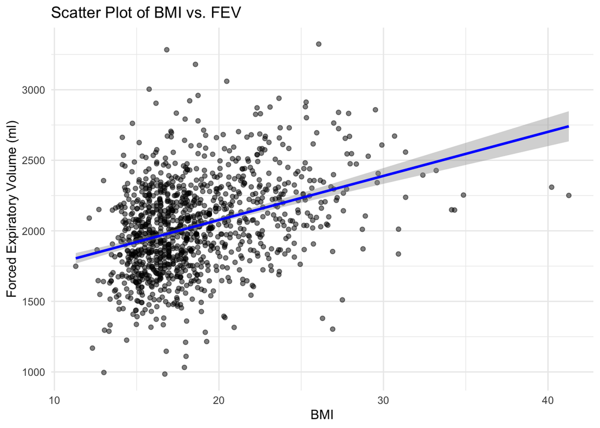

   ```r
   # Scatter plot of BMI vs. FEV
   ggplot(merged_data, aes(x = bmi, y = fev)) +
     geom_point(alpha = 0.5) +
     geom_smooth(method = "lm", color = "blue") +
     labs(title = "Scatter Plot of BMI vs. FEV",
          x = "BMI",
          y = "Forced Expiratory Volume (ml)") +
     theme_minimal()
   ```

   ```r
   # Calculate correlation
   bmi_fev_correlation <- cor(merged_data$bmi, merged_data$fev, use = "complete.obs")
   print(paste("Correlation between BMI and FEV:", bmi_fev_correlation))
   ```

   ```
   [1] "Correlation between BMI and FEV: 0.357112030981777"
   ```

   ```r
   # There is a small positive correlation between BMI and FEV
   ```

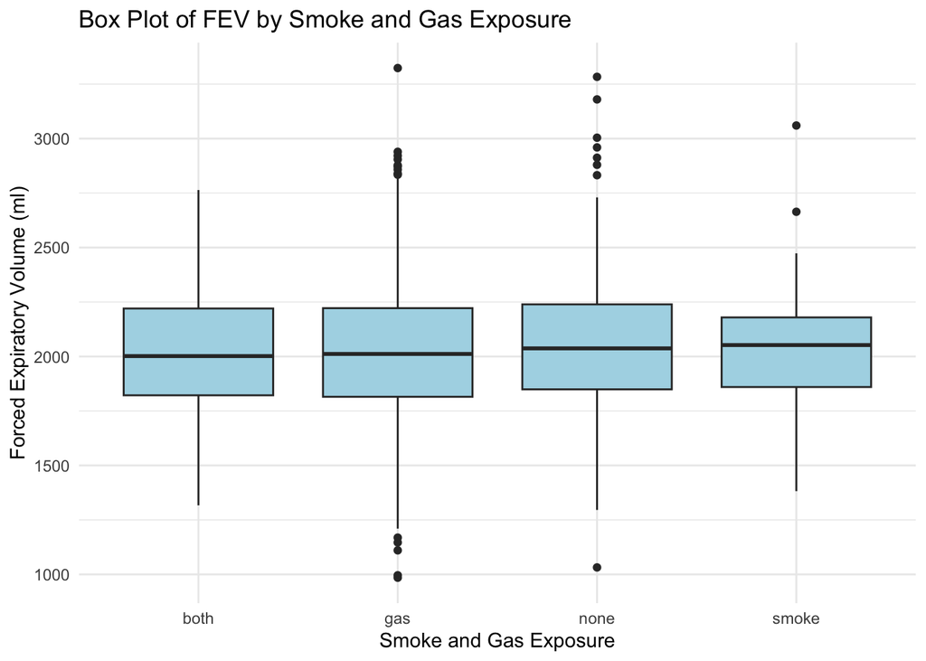

   ```r
   merged_data |>
     mutate(smoke_gas_exposure = factor(smoke_gas_exposure)) |>
     ggplot(aes(x = smoke_gas_exposure, y = fev)) +
     geom_boxplot(fill = "lightblue") +
     labs(title = "Box Plot of FEV by Smoke and Gas Exposure",
          x = "Smoke and Gas Exposure",
          y = "Forced Expiratory Volume (ml)") +
     theme_minimal()
   ```

   ```r
   # Calculate means by exposure level
   fev_means_by_exposure <- merged_data |>
     group_by(smoke_gas_exposure) |>
     summarise(median_fev = median(fev, na.rm = TRUE),
               sd_fev = sd(fev, na.rm = TRUE))
   print(fev_means_by_exposure)
   ```

   ```
   # A tibble: 4 × 3
     smoke_gas_exposure median_fev sd_fev
     <chr>                   <dbl>  <dbl>
   1 both                    2002.   301.
   2 gas                     2012.   319.
   3 none                    2037.   329.
   4 smoke                   2052.   296.
   ```

   FEV does not intitally appear to be highly related to smoke and gas exposure as all means, medians, and standard deviations are similar.
3. What is the association between PM2.5 exposure and FEV?

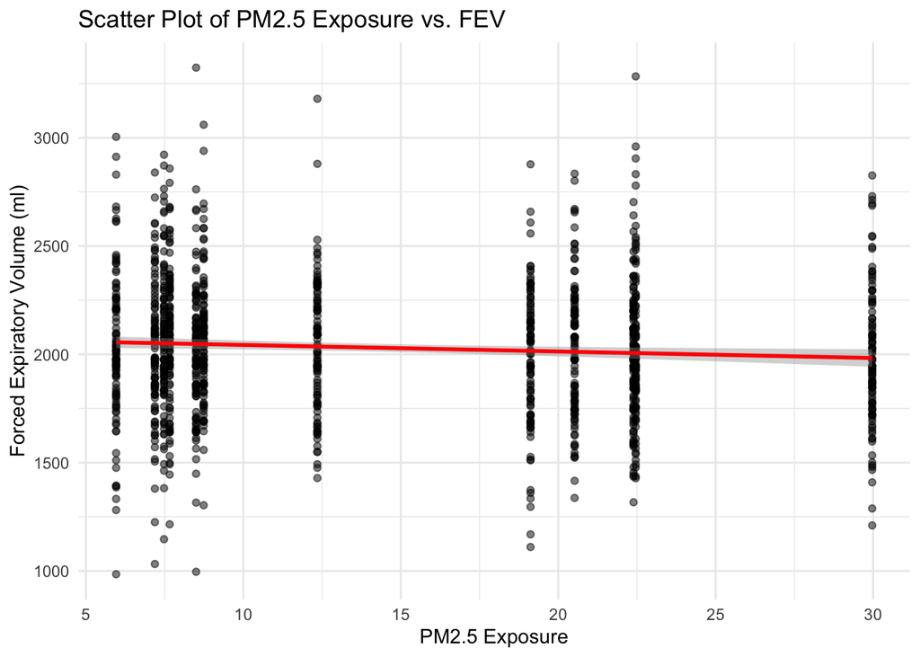

   ```r
   ggplot(merged_data, aes(x = pm25_mass, y = fev)) +
     geom_point(alpha = 0.5) +
     geom_smooth(method = "lm", color = "red") +
     labs(title = "Scatter Plot of PM2.5 Exposure vs. FEV",
          x = "PM2.5 Exposure",
          y = "Forced Expiratory Volume (ml)") +
     theme_minimal()
   ```

   ```r
   # Calculate correlation
   pm25_fev_correlation <- cor(merged_data$pm25_mass, merged_data$fev, use = "complete.obs")
   print(paste("Correlation between PM2.5 Exposure and FEV:", pm25_fev_correlation))
   ```

   ```
   [1] "Correlation between PM2.5 Exposure and FEV: -0.073413166460144"
   ```

Follow the EDA checklist from week 3 and the previous assignment. Be sure to focus on the key variables.

## Visualization

Create the following figures and interpret them. Be sure to include easily understandable axes, titles, and legends.

1. Facet plot showing scatterplots with regression lines of BMI vs FEV by “townname”.

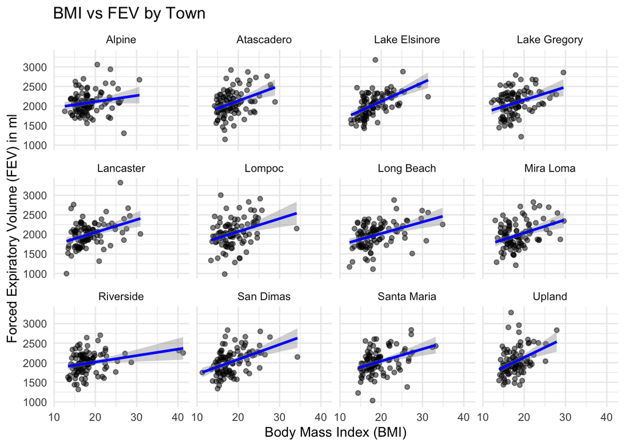

   ```r
   ggplot(merged_data, aes(x = bmi, y = fev)) +
     geom_point(alpha = 0.5) +
     geom_smooth(method = "lm", color = "blue") +
     facet_wrap(~ townname) +
     labs(title = "BMI vs FEV by Town",
          x = "Body Mass Index (BMI)",
          y = "Forced Expiratory Volume (FEV) in ml") +
     theme_minimal()
   ```

   All towns display a similar increase in FEV with BMI. Most towns have a cluster of lower BMIs, making linear extrapolation more difficult for higher BMI values. Alpine has the smallest positive correlation, while Upland has the strongest positive correlation.
2. Stacked histograms of FEV by BMI category and FEV by smoke/gas exposure. Use different color schemes than the ggplot default.

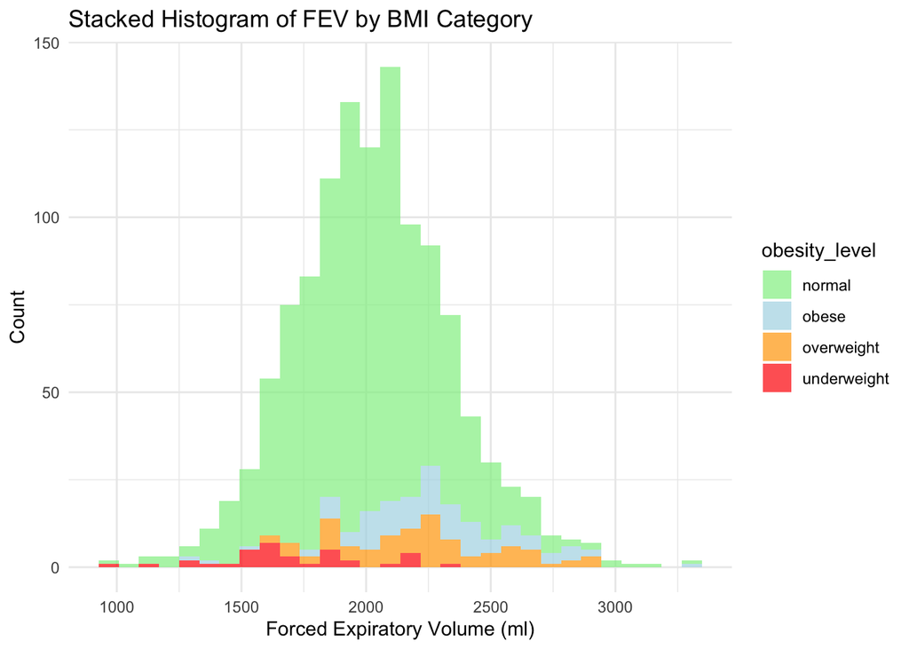

   ```r
   ggplot(merged_data, aes(x = fev, fill = obesity_level)) +
     geom_histogram(position = "stack", bins = 30, alpha = 0.7) +
     scale_fill_manual(values = c("lightgreen", "lightblue", "orange", "red")) +
     labs(title = "Stacked Histogram of FEV by BMI Category",
          x = "Forced Expiratory Volume (ml)",
          y = "Count") +
     theme_minimal()
   ```

   The normal obesity level appears to have a normal distribution of FEV values, likely because this has the highest population count. Overweight and obese categories have higher FEV modes than than the normal category, while the underweight category’s mode is lower, indicating an increase in FEV with increased BMI.

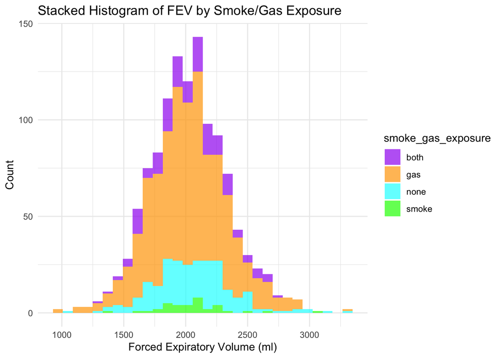

   ```r
   ggplot(merged_data, aes(x = fev, fill = smoke_gas_exposure)) +
     geom_histogram(position = "stack", bins = 30, alpha = 0.7) +
     scale_fill_manual(values = c("purple", "orange", "cyan", "green")) +
     labs(title = "Stacked Histogram of FEV by Smoke/Gas Exposure",
          x = "Forced Expiratory Volume (ml)",
          y = "Count") +
     theme_minimal()
   ```

   All types of smoke and gas exposure categories have similar FEV values with somewhat normal distributions. The smoke only group has the lowest population count, which may explain why they have a slightly higher FEV mode. Gas alone and both types of exposures have the highest population counts and similar medians to each other and with none.
3. Bar chart of BMI by smoke/gas exposure.

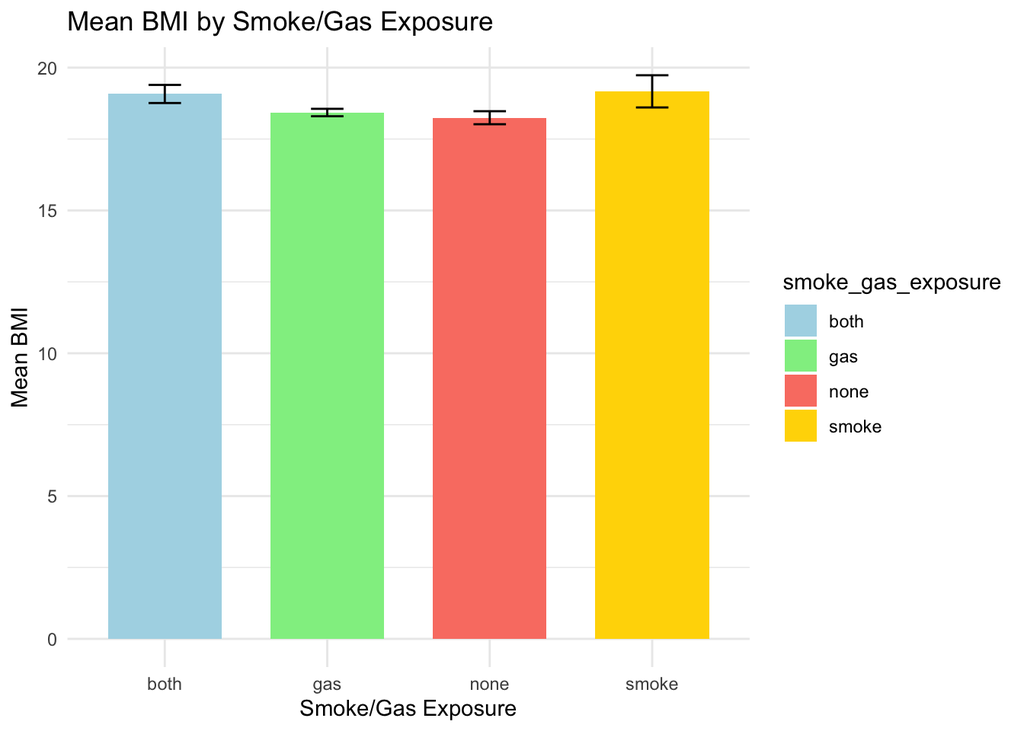

   ```r
   # Calculate bmi summary statistics to make bar chart more informative
   bmi_summary <- merged_data |>
     group_by(smoke_gas_exposure) |>
     summarise(mean_bmi = mean(bmi, na.rm = TRUE),
               sd_bmi = sd(bmi, na.rm = TRUE),
               n = n()) |>
     mutate(se_bmi = sd_bmi / sqrt(n))  # Calculates standard error

   ggplot(bmi_summary, aes(x = smoke_gas_exposure, y = mean_bmi, fill = smoke_gas_exposure)) +
     geom_bar(stat = "identity", position = "dodge", width = 0.7) +
     geom_errorbar(aes(ymin = mean_bmi - se_bmi, ymax = mean_bmi + se_bmi),
                   width = 0.2, position = position_dodge(0.7)) +
     scale_fill_manual(values = c("lightblue", "lightgreen", "salmon", "gold")) +
     labs(title = "Mean BMI by Smoke/Gas Exposure",
          x = "Smoke/Gas Exposure",
          y = "Mean BMI") +
     theme_minimal()
   ```

   Neither type of gas and smoke exposure displays a lower mean BMI than any other category. Gas exposure has slightly higher mean BMI. Having just smoke or both types of exposure is correlated with slightly higher mean BMIs, while smoke having a greater spread than both exposures.
4. Statistical summary graphs of FEV by BMI and FEV by smoke/gas exposure category.

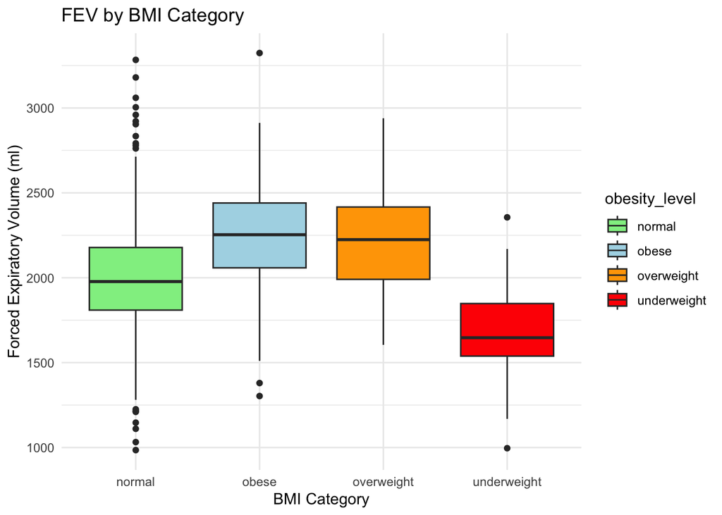

   ```r
   ggplot(merged_data, aes(x = obesity_level, y = fev, fill = obesity_level)) +
     geom_boxplot() +
     scale_fill_manual(values = c("lightgreen", "lightblue", "orange", "red")) +
     labs(title = "FEV by BMI Category",
          x = "BMI Category",
          y = "Forced Expiratory Volume (ml)") +
     theme_minimal()
   ```

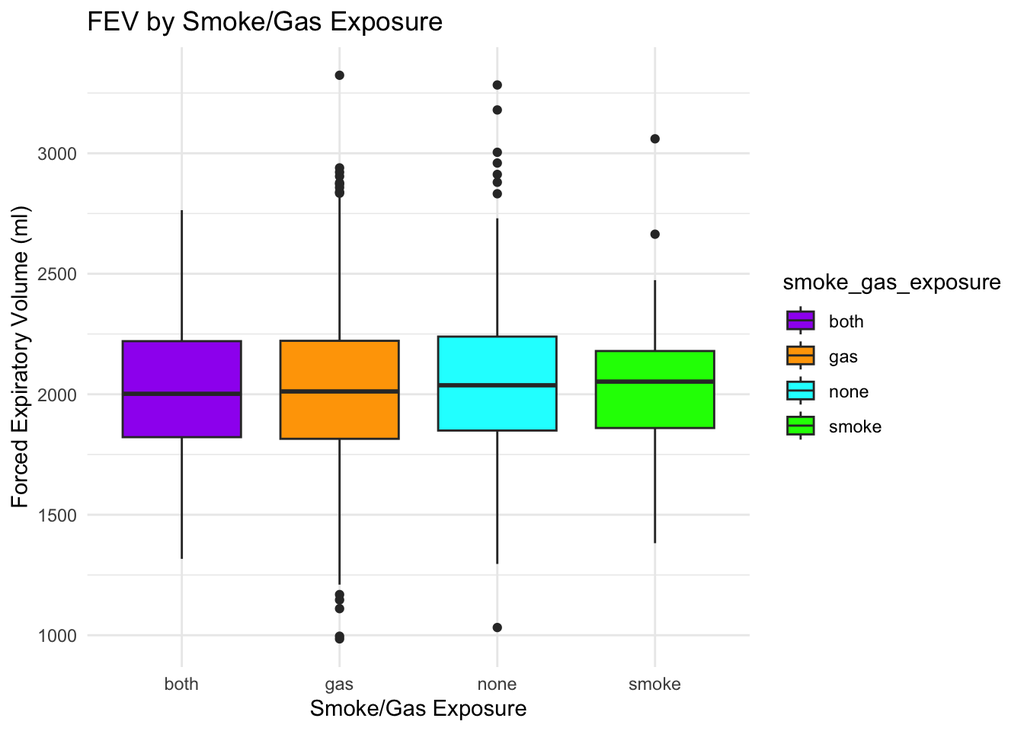

   ```r
   ggplot(merged_data, aes(x = smoke_gas_exposure, y = fev, fill = smoke_gas_exposure)) +
     geom_boxplot() +
     scale_fill_manual(values = c("purple", "orange", "cyan", "green")) +
     labs(title = "FEV by Smoke/Gas Exposure",
          x = "Smoke/Gas Exposure",
          y = "Forced Expiratory Volume (ml)") +
     theme_minimal()
   ```

   Again, all FEV levels are similar, regardless of smoke and gas exposure. Both gas and no exposure groups have many outliers. The high outliers may indicate better respiratory function for those with lower exposure levels, but with limited data and confounding variables, this hypothesis is not substantiated by the data.
5. A leaflet map showing the concentrations of PM2.5 mass in each of the CHS communities.

   ```r
   leaflet(merged_data) |>
     addTiles() |>
     addCircles(
       lat = ~lat,
       lng = ~lon,
       radius = 10000,  # Scale circle size by PM2.5 value
       color = ~colorFactor(brewer.pal(9, "PuRd"), domain = merged_data$pm25_mass)(pm25_mass),
       stroke = FALSE,
       fillOpacity = 0.5,
       popup = ~paste("PM2.5: ", pm25_mass)
     ) |>
     setView(lng = mean(merged_data$lon), lat = mean(merged_data$lat), zoom = 7) |>
     addLegend("bottomright", pal = colorFactor(brewer.pal(9, "PuRd"), NULL), values = ~pm25_mass,
               title = "PM2.5 Concentration", opacity = 1)
   ```

[interactive chart not shown]

   The PM2.5 concentrations have a wide range. The highest values appear to be inland of Los Angeles, while lower values are found in less populated areas/rural aeras, like near Lake Arrowhead and Vandenberg Space Fore Base
6. Choose a visualization to examine whether PM2.5 mass is associated with FEV.

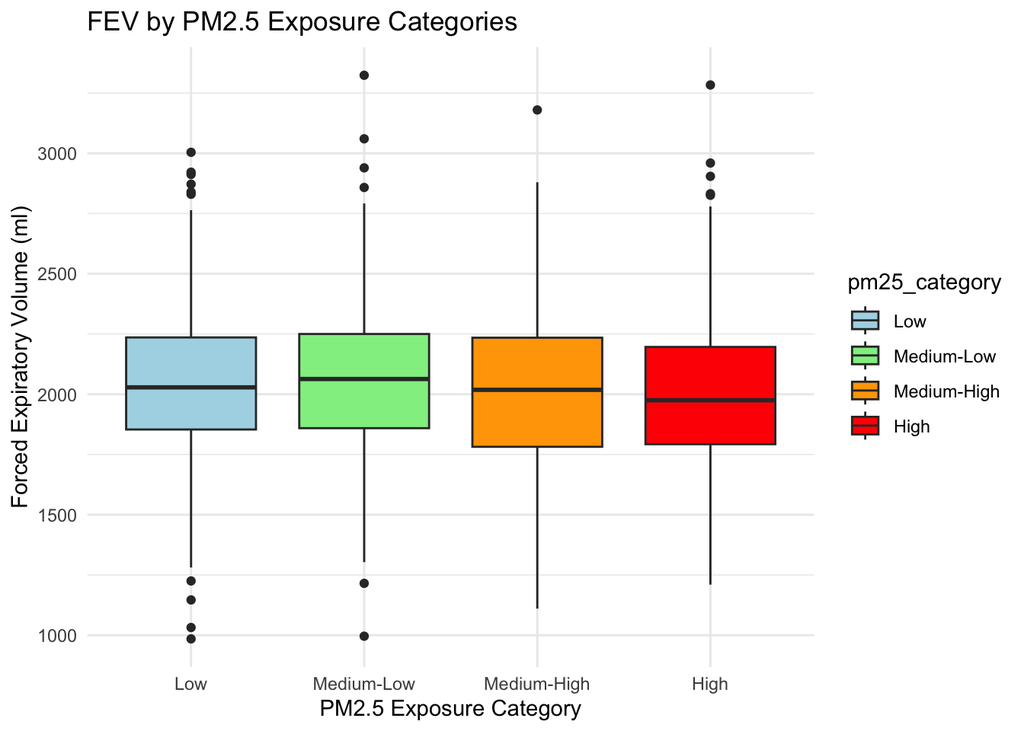

   ```r
   # Create PM2.5 categories based on quantiles
   merged_data <- merged_data |>
     mutate(pm25_category = cut(pm25_mass,
                                 breaks = quantile(pm25_mass, probs = seq(0, 1, 0.25), na.rm = TRUE),
                                 include.lowest = TRUE,
                                 labels = c("Low", "Medium-Low", "Medium-High", "High")))

   # Box plot for the caregories vs FEV
   ggplot(merged_data, aes(x = pm25_category, y = `fev`, fill = pm25_category)) +
     geom_boxplot() +
     scale_fill_manual(values = c("lightblue", "lightgreen", "orange", "red")) +
     labs(title = "FEV by PM2.5 Exposure Categories",
          x = "PM2.5 Exposure Category",
          y = "Forced Expiratory Volume (ml)") +
     theme_minimal()
   ```

   FEV does not appear to be correlated with PM2.5 mass, as all categories of exposure have similar mean FEV values and similar variance. There is no trend in the average FEV values.